# Data Visualization: preparing your figures for an audience

Morgan Feeney, Leighton Pritchard

2022 Presentation

- Your figures should be clear and informative, allowing the reader to easily and quickly understand the data that you present.
- Design decisions, including layout and the use of white space, colour choices, font size and choice, all matter in terms of making your figure clear and easy to interpret.
- Your figures should be designed with accessibility in mind: for example, you should use colourblind-friendly colour palettes, and dyslexia-friendly fonts.

# 1 Introduction

You are the author of your figures: not their intended audience. It is important, when you create any figure, to take a few moments to consider how a naive audience (one who hasn’t seen the figure before) will perceive it.

It is also essential that you consider *accessibility*: is your figure accessible to a broad audience? Or does it rely on niche jargon specific to a particular field, colour palettes that are difficult/impossible for some readers to see, and/or fonts that are difficult for some readers to read?

Unfortunately, many scientific figures are poorly designed. They are difficult to interpret, confuse the reader, and/or distract from the message that the authors mean to convey.

[figure not shown]

Figure 1.1: A picture with a thousand words… [PhD Comics](http://phdcomics.com/comics/archive.php?comicid=1926)

Do not mislead your audience! The figure should be a faithful representation of the data. Omitting data (such as “outliers”), skewing the axes on a graph, or leaving out key information, can lead the reader to draw incorrect conclusions. Unscrupulous use of colour (highlighting some data to make it more prominent, or making some data appear linked when in fact they are not) can also be very problematic. Always double check your final figure to make certain that it represents your data correctly.

# 2 Figure aesthetics

Your audience will form an impression of your figure within the first 30 seconds (or less) of looking at it. First impressions matter - and you want that first impression to be pleasant, not an exercise in confusion or frustration.

The example below shows what a lot of work reading a figure can be, if a reader has to move their gaze back and forth between the key and the graph in order to figure out what the different colours represent and what the data are. The same principle applies to looking back and forth between the figure and the figure legend. It’s hard work that the reader shouldn’t have to do: make it easy for them to see and interpret the data.

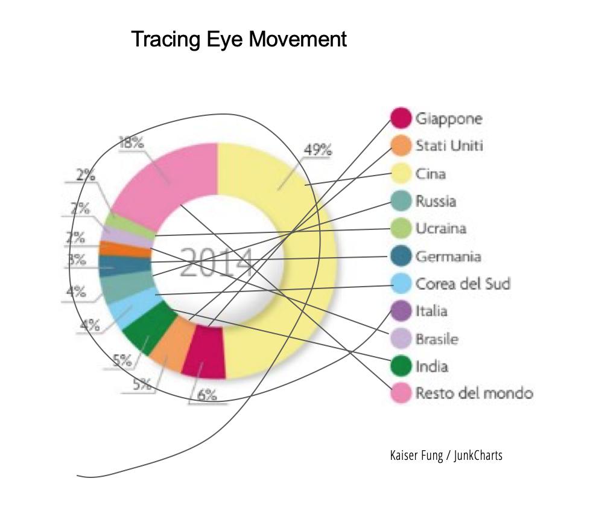

Figure 2.1: Tracing eye movements between a figure and the associated legend, From: [Junk Charts](https://junkcharts.typepad.com/junk_charts/2021/04/come-si-dice-donut-in-italiano.htmll)

# 3 Colors

It is very tempting to use colour in scientific figures, and the use of colour can, indeed, help to visualize data. But there are a number of important factors to consider when choosing to use colour in a figure.

Consider how the reader will perceive the colours that you are using:

- Do the colours help to illuminate key aspects of your data? Or do they distract from and/or distort the data?
- Will all readers be able to clearly perceive differences between the colours you are using?
- Do the colour choices correspond with our natural and/or cultural associations with those colours? (e.g., in general darker colours = more; blue = water; etc.)

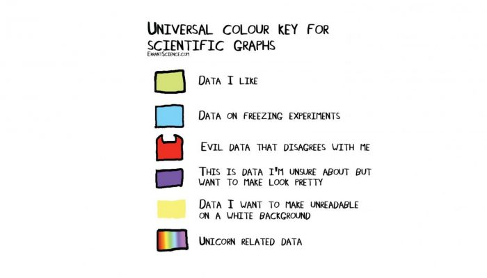

Figure 3.1: Choosing colours for a scientific figure, From: [Errant Science](https://blogs.egu.eu/divisions/gd/2017/08/23/the-rainbow-colour-map/)

Using colours can help to visualize data in some cases; but colours can distract the reader. In the examples below, we naturally try to find meaning in the colours (meaningless colours: what do all the green-coloured countries have in common? or too many colours: do the colours mean something?) - but this distracts the reader for no purpose.

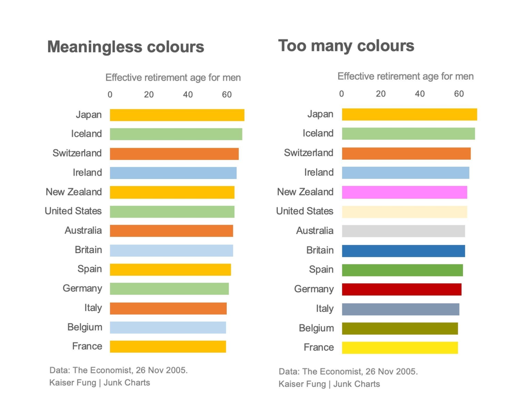

Figure 3.2: Different colours in a figure chosen for no particular reason, From: [The Unspoken Rules of Visualization](https://datajournalism.com/read/longreads/the-unspoken-rules-of-visualisation)

Do not use colour for the sake of using colour.[^1] Poor colour choices can distort our visual perception of the data, making it harder for the reader to correctly interpret a figure. In the example shown below, it is much easier to see the differences in height clearly when the chart is in gray; using colours, here, can distort our perceptions.

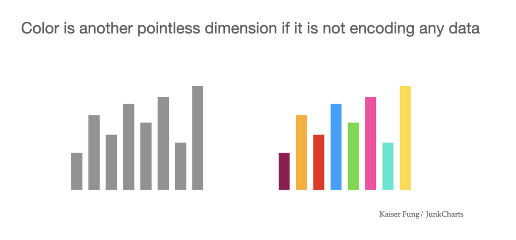

Figure 3.3: Pointless use of colour can distort our perception of the data, From: [Junk Charts](https://junkcharts.typepad.com/junk_charts/2021/06/distorting-perception-versus-distorting-the-data.html)

Be intentional with your use of colour: use colours to focus the reader’s attention on important differences in your data.

## 3.1 Colour choices and differences and gradients, oh my!

If you are going to use colour in your figures, the question becomes: which colour(s)? The choice of colour usually depends on the underlying data that you are presenting.

As a general rule, use sequential palettes (gradients) to present quantitative data. These make it easier for readers to order the data. Avoid any thresholds (jumps between colours), as these can make data points seem artificially far apart.

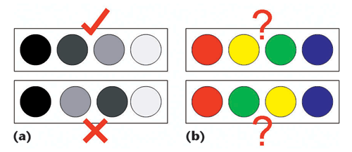

Figure 3.4: Ordering data: gradient versus different colours, From: D. Borland and R. Taylor II, “Rainbow Color Map (Still) Considered Harmful” in IEEE Computer Graphics and Applications, vol. 27, no. 02, pp. 14-17, 2007.

On the other hand, for categorical data, using a colour palette without an obvious order makes sense. Choose colours that can be easily distinguished from one another.

## 3.2 Colour-blind friendly palettes

When choosing colour palettes, it is important to keep in mind that your reader may perceive colour differently than you do. Red-green colourblindness is common, but it is important to note that it is not the only form of colourblindness.

Unfortunately, red and green are commonly used together in certain types of biological images, perhaps especially in microscopy (e.g., immunofluorescence images). These micrographs are particularly difficult to view and understand for individuals with certain forms of colourblindness, as illustrated in the figure below that simulates protanophy and deuteranophy (two common forms of colourblindness).

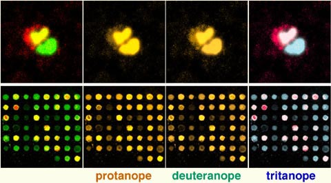

Figure 3.5: Red-green colours in biological images, From: [Color Universal Design](https://jfly.uni-koeln.de/color/)

This problem can be easily addressed by using colourblind-friendly colour combinations; for example, by substituting magenta instead of red, as shown below.

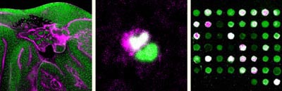

Where possible, add textures, symbols or labels (in addition to colour), to improve the accessibility and readability of your figures.

Many software include options to check whether your images are colourblind-accessible. There are also online tools that simulate colourblindness, which can be helpful in checking whether your figures are colourblind-accessible, for instance:

- [Coblis](https://www.color-blindness.com/coblis-color-blindness-simulator/)
- [ColorOracle](https://colororacle.org/)

See [Picking a colour scale for scientific graphics](https://betterfigures.org/2015/06/23/picking-a-colour-scale-for-scientific-graphics/) for more advice.

# 4 Text

Any text present in a figure should be clear and easy to read.

Some labels are essential for understanding a figure (e.g. axis labels, units, scale bars in micrographs). Too much text can be overwhelming, however, and make it take much longer for the reader to understand the figure.

## 4.1 Labels

To label your data directly or use a key, that is the question.

Using a key or putting the data labels in the figure legend means that the reader has to do quite a lot of work to figure out what the data are (see Figure 2.1 and the example below).

In this figure showing a DNase I footprinting experiment, the labels on the right of the figure help the reader understand the relative positions of different nucleotides, and figure out where Region A and Region B are - these labels are very helpful.

However, the lanes are labelled only with numbers - the reader has to read and understand the legend, and then look back and forth between the legend and t he figure, to determine which sample is in each of the lanes. Where possible, it is better to label the data with brief, descriptive names (giving more detail in the figure legend if necessary).

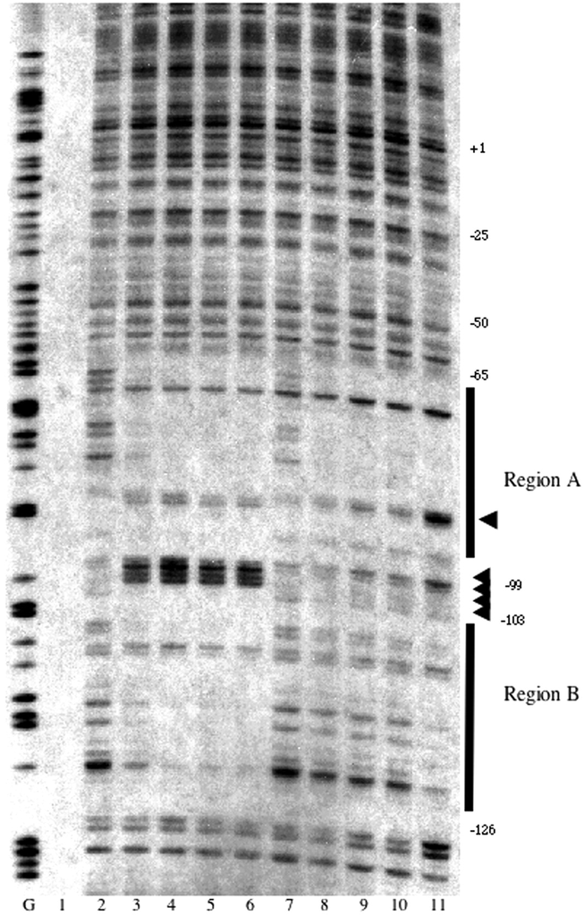

However, labels can also become unwieldy, as shown in the pie chart below. This figure is hard to read for a number of reasons, but a major problem with it is that it is very difficult to determine which label belongs to which section of the pie chart.

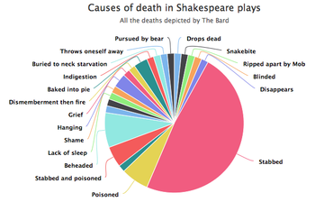

Figure 4.2: Pie chart showing causes of death in Shakespeare plays, From: [JunkCharts](https://junkcharts.typepad.com/junk_charts/2016/03/which-way-to-die-the-bard-asked-onelesspie.html)

## 4.2 Font choices

Use [dyslexic friendly fonts](https://www.bdadyslexia.org.uk/advice/employers/creating-a-dyslexia-friendly-workplace/dyslexia-friendly-style-guide) such as Arial.

Avoid using Comic Sans, and any fonts with unnecessary flourishes or embellishments.

# 5 Negative space

Negative space is the space between elements in your figure (also known as whitespace). It helps to frame the elements, and when used effectively, can help draw the reader’s attention to particular elements.[^2]

Data that is too crowded is harder for the reader to view and interpret correctly. It can feel claustrophobic, too. Give your figures a little space to breathe.

# 6 Remove distractions

You want your figures to tell a clear, easy to read message - this means that you should remove anything that might distract your audience from that message.  
It is often tempting to present *all* of the data (it might be useful! you generated the data, so you should show it! you want to impress your audience!). However, this is often a mistake.

- *Do* include the key data and all of the controls necessary to understand and interpret those data.
- *Don’t* include any data that you do not discuss in the text of your thesis.

# 7 Further reading

- [Junk Charts](https://junkcharts.typepad.com/)
- [Nature Methods: Points of View columns](http://blogs.nature.com/methagora/2013/07/data-visualization-points-of-view.html)
- Rougier NP, Droettboom M, Bourne PE (2014) Ten Simple Rules for Better Figures. PLOS Computational Biology 10(9): e1003833. https://doi.org/10.1371/journal.pcbi.1003833
- Jambor H, Antonietti A, Alicea B, Audisio TL, Auer S, et al. (2021) Creating clear and informative image-based figures for scientific publications. PLOS Biology 19(3): e3001161. https://doi.org/10.1371/journal.pbio.3001161
[^1]: For practical reasons, if nothing else: print journals usually charge additional money to print colour figures.
[^2]: [Points of View: Negative Space](https://www.nature.com/articles/nmeth0111-5)